# PaleoFidelity

Michal Kowalewski

2024-08-15

## Introduction

The package “PaleoFidelity” carries out paleontological fidelity analyses focused on live-dead comparisons. Designed for compositional/enumeration data (e.g., specimen counts of taxa), the package can be used for a single site or sets of sites. A grouping factor can be provided to carry out comparative analyses of sites grouped by a factor (e.g., habitat, region, time interval).

Currently, the following functions are provided:

1. **FidelitySummary** performs data assessment prior to any other analysis.
2. **LDPlot** plots a comparative live-dead plot for the *n* most common taxa and provides a short numerical summary of live-dead fidelity
3. **FidelityEst** performs compositional fidelity analysis based on correlation/similarity measures.
4. **FidelityDiv** performs alpha diversity/evenness analysis (live-dead offsets in standardized diversity/evenness).
5. **SJPlot** plots a fidelity cross-plot of correlation and similarity measures
6. **AlphaPlot** plots a fidelity cross-plot of live-dead offsets in alpha diversity and evenness

## Installing PaleoFidelity Package

The most updated beta version of the package is available at github. To install:

```r
install.packages('devtools')
library(devtools)
devtools::install_github('mjkowalewski/PaleoFidelity', build_vignettes = TRUE)
library(PaleoFidelity)
```

## Example datasets

A live-data dataset (FidData) is included. This is a subset of a marine benthos survey data conducted along the coast of North Carolina, USA (for more info see Tyler and Kowalewski 2017, 2018).

```r
library(PaleoFidelity)
str(FidData) # check the structure of the dataset
```

```
#> List of 4
#>  $ live      : int [1:44, 1:202] 0 0 0 1 4 0 0 92 0 1 ...
#>   ..- attr(*, "dimnames")=List of 2
#>   .. ..$ : chr [1:44] "locality 1" "locality 2" "locality 3" "locality 4" ...
#>   .. ..$ : chr [1:202] "species 1" "species 2" "species 3" "species 4" ...
#>  $ dead      : int [1:44, 1:202] 0 1 6 70 52 1 0 52 1 0 ...
#>   ..- attr(*, "dimnames")=List of 2
#>   .. ..$ : chr [1:44] "locality 1" "locality 2" "locality 3" "locality 4" ...
#>   .. ..$ : chr [1:202] "species 1" "species 2" "species 3" "species 4" ...
#>  $ habitat   : Factor w/ 2 levels "nearshore","offshore": 2 2 2 1 1 2 2 1 1 1 ...
#>  $ fossiltype: Factor w/ 2 levels "durable","fragile": 2 2 2 2 2 2 2 2 2 2 ...
```

FidData dataset is a single list with 4 items, but datasets can be stored as separate objects. Live and dead datasets must be formatted as matrices and their dimensions must match. The grouping factor variable should be univariate.

For a single sample live-dead analysis, format ‘live’ and ‘dead’ specimen counts as one-row matrices.

## FidelitySummary Function

A function *FidelitySummary* assesses data for format compliance and numerical adequacy. The function allows to filter rare taxa and small samples. A report summarizing the filtered dataset can be requested. This function is called by other PaleoFidelity functions and the data filters should be set in those functions before the analysis is carried out. When the argument report is set to TRUE, a report, notes, and warnings are printed.

```r
FidelitySummary(live = FidData$live, dead = FidData$dead, gp = FidData$habitat, report = TRUE)
```

```
#> NOTE: n.filters=0: no samples (rows) were removed
#> NOTE: n.filters=0, 0 samples (rows) removed, 0 taxa (columns) removed
#> Warning in FidelitySummary(live = FidData$live, dead = FidData$dead, gp =
#> FidData$habitat, : small samples present (n<30): consider applying "n.filters
#> >= 30"
#>                                       outcomes
#> number of live samples                      44
#> number of dead samples                      44
#> number of live taxa                        125
#> number of dead taxa                        135
#> total number of taxa                       202
#> number of live specimens                  8479
#> number of dead specimens                 40093
#> smallest sample (live)                      20
#> smallest sample (dead)                      17
#> number of levels in "gp" factor              2
#> number of observations in "gp" factor       44
#> number of levels with n > 1                  2
```

The report summarizes sample and variable data and notes if any data were removed. In this example, the report confirmed that the grouping factor included 2 levels with more than one sample allowing for by-group analyses and produced a warning about small samples with *n* < 30.

The *FidelitySummary* function allows for exploring the effects of applying different filters (e.g., removing samples *n* < 30).

```r
FidelitySummary(live = FidData$live, dead = FidData$dead, gp = FidData$habitat,
                report = TRUE, n.filters = 30)
```

```
#> NOTE: n.filters=30, 6 samples (rows) removed, 0 taxa (columns) removed
#>                                       outcomes
#> number of live samples                      38
#> number of dead samples                      38
#> number of live taxa                        124
#> number of dead taxa                        135
#> total number of taxa                       202
#> number of live specimens                  8252
#> number of dead specimens                 39906
#> smallest sample (live)                      31
#> smallest sample (dead)                      32
#> number of levels in "gp" factor              2
#> number of observations in "gp" factor       38
#> number of levels with n > 1                  2
```

With n.filters set to 30, a total of 6 sites were lost but the factor levels still included more than 1 site per level. Also, no taxa were lost (i.e., the removed sites did not contain unique species) so data dimensionality was not reduced.

```r
FidelitySummary(live = FidData$live, dead = FidData$dead, gp = FidData$habitat, report = TRUE, n.filters = 100)
```

```
#> NOTE: n.filters=100, 23 samples (rows) removed, 12 taxa (columns) removed
#>                                       outcomes
#> number of live samples                      21
#> number of dead samples                      21
#> number of live taxa                        110
#> number of dead taxa                        134
#> total number of taxa                       190
#> number of live specimens                  6413
#> number of dead specimens                 34589
#> smallest sample (live)                     102
#> smallest sample (dead)                     126
#> number of levels in "gp" factor              2
#> number of observations in "gp" factor       21
#> number of levels with n > 1                  2
```

With n.filters set to 100, 12 taxa were lost and only 21 sites were retained. Thus, 100 may be an unreasonably high filter for this dataset. Once optimal filters are identified, they can be used in other fidelity functions.

## LDPlot Function

A function *LDPlot* is designed to analyze and visualize a single live-dead comparison. The function returns a plot that compares the top *n* species/variables in terms of rank abundance. This function accepts vectors. It also provides an option to output a report with summary statistics and expected values under the null model of perfect fidelity.

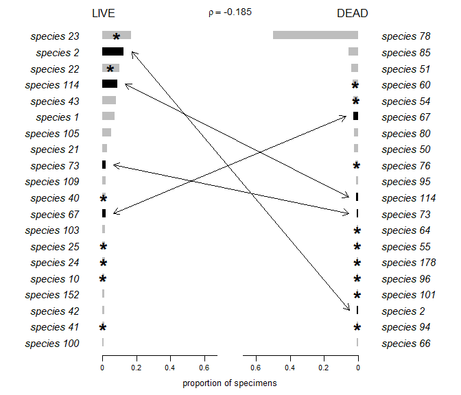

```r
par(mar=c(3, 7, 0.5, 7))
rep1 <- LDPlot(live = colSums(FidData$live),
       dead = colSums(FidData$dead),
       tax.names = colnames(FidData$live), toplimit = 20,
       cor.measure = 'spearman', report = TRUE, iter = 1000)
```

The graph indicates low compositional fidelity: (1) very few top live species are present among dead species and vice versa; (2) some of the top live taxa are also completely missing in dead dataset, and vice versa (taxa marked by asterisks); and (3) Spearman rank correlation estimate is low. This is not surprising given that live data include many species without hard skeleton.

The report=TRUE produces a list of 8 items, which include summary tables for the top live and dead taxa, numerical and statistical summaries, expected correlation statistics and the statistical significance values of observed statistics based on a resampling simulation of perfect fidelity (explained below). When p = 0, p values are reported as p < 1 / number of iterations.

```r
rep1[1:7]
```

```
#> $top.live
#>             rank       prop found.dead
#> species 23     1 0.16900578          0
#> species 2      2 0.12690176          1
#> species 22     3 0.10036561          0
#> species 114    4 0.08916146          1
#> species 43     5 0.08019814          1
#> species 1      6 0.07158863          1
#> species 105    7 0.05401580          1
#> species 21     8 0.02889492          1
#> species 73     9 0.02134686          1
#> species 109   10 0.01969572          1
#> species 40    11 0.01898809          0
#> species 67    12 0.01875221          1
#> species 103   13 0.01639344          1
#> species 25    14 0.01627550          0
#> species 24    15 0.01603963          0
#> species 10    16 0.01214766          0
#> species 152   17 0.01191178          1
#> species 42    18 0.01132209          1
#> species 41    19 0.01096827          0
#> species 100   20 0.01014271          1
#>
#> $top.dead
#>             rank        prop found.live
#> species 78     1 0.498865139          1
#> species 85     2 0.057341681          1
#> species 51     3 0.039907216          1
#> species 60     4 0.034519742          0
#> species 54     5 0.029306862          0
#> species 67     6 0.028558601          1
#> species 80     7 0.025116604          1
#> species 50     8 0.024917068          1
#> species 76     9 0.015040032          0
#> species 95    10 0.013867757          1
#> species 114   11 0.012296411          1
#> species 73    12 0.010575412          1
#> species 64    13 0.010026688          0
#> species 55    14 0.009677500          0
#> species 178   15 0.009403138          0
```

[output cut: 14 more lines]

```
#>
#> $sample.info
#>    total n total live total dead
#>      48572       8479      40093
#>
#> $cor.coeff
#>      pearson     spearman      kendall
#> -0.004958471 -0.184948892 -0.144335215
#>
#> $expected.coeff
#>   pearson  spearman   kendall
#> 0.9998250 0.9426052 0.8567568
#>
#> $p.values
#> [1] "< 0.001" "< 0.001" "< 0.001"
```

The function also stores correlation values (randomized.r in the report output) produced by the resampling protocol modelling perfect fidelity. In the model, observations are resampled from the pooled live-dead data resulting in live and dead replicate samples that came from the same species abundance distribution (i.e., perfect live-dead agreement). This resampling procedure estimates the expected under-sampling bias in the three common correlation statistics (pearson, spearman, and kendall). The distribution can be plotted to compare against the observed value.

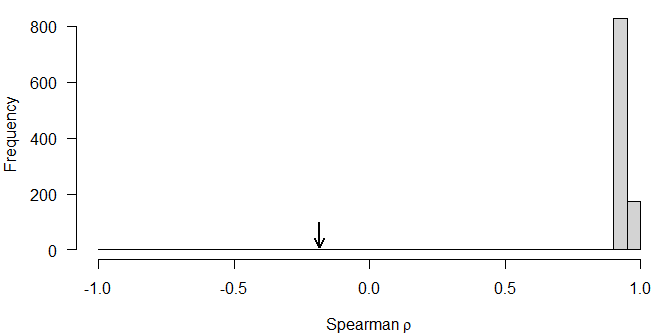

```r
par(mar=c(4, 4, 0.5, 0.5))
hist(rep1$randomized.r[,2], breaks=seq(-1,1,0.05), main='',
     las=1, xlab=bquote('Spearman' ~ italic(rho)))
arrows(rep1$cor.coeff[2], 100, rep1$cor.coeff[2], 10,
       length=0.1, lwd=2)
```

In this example, the expected distribution of spearman rho values approaches rho = 1, which means that the effect of sampling bias is minimal. Inadequate sampling cannot explain the low observed rho value.

## FidelityEst Function

A function *FidelityEst* returns compositional fidelity estimates by comparing live and dead datasets. The function returns fidelity estimates for individual sites and for groups of sites if ‘gp’ factor is provided. The function produces two types of compositional fidelity estimates:

1. $x - a measure of correlation/association: Spearman, Kendall, or Pearson.
2. $y - an abundance-based measure of similarity such as Bray-Curtis or Jaccard-Chao.

Because fidelity measures are sensitive to under-sampling or unbalanced sampling, *FidelityEst* function implements two bias corrections: (1) estimating under-sampling biases and (2) standardizing sampling coverage.

In the first approach, the bias is estimated using a resampling protocol under the perfect fidelity (PF) model, in which pooled data (live + dead) are randomly subsampled into replicate pairs of live and dead pseudo-samples (using sample sizes of original live and dead samples), thus creating live-dead pairs derived from single underlying rank abundance species distributions (i.e., the perfect fidelity). The same approach is used in *LDPlot* function discussed above. For an unbiased estimator, the resampled fidelity measures should indicate perfect fidelity (e.g., Spearman rho = 1). The offset between the expected observed PF value (1 - PF) provides a data-specific estimate of sampling bias. The adjusted fidelity measure is then given by Adjusted = Observed + (1 - PF). Replicate resampling produces a distribution of PF values and resulting adjusted fidelity measures, from which confidence intervals and significance tests can be derived.

In the second approach, fidelity measures are computed for sample standardized data, where all samples are subsampled to a sample size given by the smallest sample. Replicate resampling produces a distribution of sample-standardized fidelity estimates used to generate confidence intervals and means for standardized fidelity estimates.

When the data include multiple sites that can be grouped into subsets, *FidelityEst* will report mean fidelity estimates for total data and each group. Two measures are reported: a correlation measure (default=Spearman) and a similarity measure (default=Chao). Note also that correlation can be computed with double zeroes included or excluded. In the example below, double zeroes were kept, which is the recommended (default) approach.

*FidelityEst* function returns a *FidelityEst* class object that can be used to plot a Fidelity Plot: *SJPlot* function (see below). The object is a list and its structure is illustrated below.

```r
out1 <- FidelityEst(live = FidData$live, dead = FidData$dead,
                    gp = FidData$habitat,
                    n.filters = 30, iter = 499)
str(out1)
```

```
#> List of 22
#>  $ x        : Named num [1:38] -0.03726 -0.00229 0.10466 0.01625 0.04245 ...
#>   ..- attr(*, "names")= chr [1:38] "locality 1" "locality 2" "locality 3" "locality 4" ...
#>  $ y        : Named num [1:38] 0 0.0291 0.2248 0.0897 0.1254 ...
#>   ..- attr(*, "names")= chr [1:38] "locality 1" "locality 2" "locality 3" "locality 4" ...
#>  $ xc       : num [1:38, 1:4] 0.269 0.347 0.354 0.363 0.224 ...
#>   ..- attr(*, "dimnames")=List of 2
#>   .. ..$ : chr [1:38] "locality 1" "locality 2" "locality 3" "locality 4" ...
#>   .. ..$ : chr [1:4] "spearman.ADJ" "0.025" "0.975" "spearman.PF"
#>  $ yc       : num [1:38, 1:4] 0.035 0.0562 0.249 0.1014 0.1308 ...
#>   ..- attr(*, "dimnames")=List of 2
#>   .. ..$ : chr [1:38] "locality 1" "locality 2" "locality 3" "locality 4" ...
#>   .. ..$ : chr [1:4] "chao.ADJ" "0.025" "0.975" "chao.PF"
#>  $ xs       : num [1:38, 1:4] -0.0312 0.0116 0.0794 0.1119 0.108 ...
#>   ..- attr(*, "dimnames")=List of 2
#>   .. ..$ : chr [1:38] "locality 1" "locality 2" "locality 3" "locality 4" ...
#>   .. ..$ : chr [1:4] "spearman.SS" "0.025" "0.975" "n.std"
#>  $ ys       : num [1:38, 1:4] 0 0.0223 0.0753 0.0661 0.0735 ...
#>   ..- attr(*, "dimnames")=List of 2
#>   .. ..$ : chr [1:38] "locality 1" "locality 2" "locality 3" "locality 4" ...
#>   .. ..$ : chr [1:4] "chao.SS" "0.025" "0.975" "n.std"
#>  $ x.stats  : num [1:3, 1] 0.0587 0.0697 0.0376
#>   ..- attr(*, "dimnames")=List of 2
#>   .. ..$ : chr [1:3] "all samples" "nearshore" "offshore"
#>   .. ..$ : NULL
#>  $ y.stats  : num [1:3, 1] 0.1334 0.1532 0.0953
#>   ..- attr(*, "dimnames")=List of 2
#>   .. ..$ : chr [1:3] "all samples" "nearshore" "offshore"
#>   .. ..$ : NULL
#>  $ xc.stats : num [1:3, 1:4] 0.352 0.334 0.386 0.173 0.172 ...
#>   ..- attr(*, "dimnames")=List of 2
#>   .. ..$ : chr [1:3] "all.samples" "nearshore" "offshore"
#>   .. ..$ : chr [1:4] "mean" "0.025" "median" "0.975"
#>  $ yc.stats : num [1:3, 1:4] 0.1536 0.1682 0.1255 0.0334 0.0359 ...
#>   ..- attr(*, "dimnames")=List of 2
#>   .. ..$ : chr [1:3] "all.samples" "nearshore" "offshore"
#>   .. ..$ : chr [1:4] "mean" "0.025" "median" "0.975"
#>  $ xs.stats : num [1:3, 1:4] 0.0621 0.0767 0.0341 0.0493 0.0669 ...
#>   ..- attr(*, "dimnames")=List of 2
#>   .. ..$ : chr [1:3] "all samples" "nearshore" "offshore"
```

[output cut: 31 more lines]

```
#>   .. ..$ : chr [1:38] "locality 1" "locality 2" "locality 3" "locality 4" ...
#>   .. ..$ : chr [1:202] "species 1" "species 2" "species 3" "species 4" ...
#>  $ dead     : int [1:38, 1:202] 0 1 6 70 52 1 0 52 1 0 ...
#>   ..- attr(*, "dimnames")=List of 2
#>   .. ..$ : chr [1:38] "locality 1" "locality 2" "locality 3" "locality 4" ...
#>   .. ..$ : chr [1:202] "species 1" "species 2" "species 3" "species 4" ...
#>  $ gp       : Factor w/ 2 levels "nearshore","offshore": 2 2 2 1 1 2 2 1 1 1 ...
#>  $ values   :List of 6
#>   ..$ measures           : chr [1:2] "spearman" "chao"
#>   ..$ data.transf        : chr "none"
#>   ..$ remove.double.zeros: logi FALSE
#>   ..$ PFiter             : num 499
#>   ..$ SSIter             : num 10
#>   ..$ min.sam            : num 30
#>  - attr(*, "class")= chr [1:2] "list" "FidelityEst"
```

*FidelityEst* function returns the adjusted fidelity measures ($xc, $yc) with a correction based on a resampling model simulating ‘Perfect Fidelity’ (discussed above). In addition, mean values for all samples and sample groups are also reported (if factor ‘gp’ is provided).

```r
out1$xc # adjusted correlation measure summary
```

```
#>             spearman.ADJ      0.025     0.975 spearman.PF
#> locality 1     0.2685185 0.08588229 0.4743353   0.6967503
#> locality 2     0.3472204 0.24256241 0.4592672   0.6518116
#> locality 3     0.3543609 0.29627540 0.4139349   0.7521017
#> locality 4     0.3630609 0.30763492 0.4188800   0.6541110
#> locality 5     0.2242559 0.15974658 0.2910329   0.8203100
#> locality 6     0.3939014 0.23089796 0.5545115   0.6254871
#> locality 7     0.3694581 0.25371356 0.4931467   0.7244573
#> locality 8     0.3282974 0.28352757 0.3801094   0.7560072
#> locality 9     0.2541201 0.19716912 0.3158438   0.8141048
#> locality 16    0.1715034 0.13766127 0.2120540   0.8316042
#> locality 18    0.1728994 0.11259986 0.2421927   0.8325637
#> locality 19    0.4497088 0.39689717 0.5081693   0.7177751
#> locality 20    0.3372129 0.25055473 0.4417638   0.7632404
#> locality 23    0.1868739 0.12729768 0.2584702   0.7770169
#> locality 24    0.6093806 0.53989554 0.6824190   0.6474908
#> locality 25    0.2650815 0.18173474 0.3565509   0.7439149
#> locality 26    0.4946140 0.40004648 0.5891030   0.6291159
#> locality 27    0.6499366 0.56983526 0.7337704   0.5156800
#> locality 28    0.4497956 0.37278773 0.5369814   0.5308452
#> locality 29    0.4052847 0.32912381 0.4922227   0.7251866
#> locality 30    0.3383537 0.24094332 0.4433518   0.6936943
#> locality 31    0.3452888 0.26347341 0.4286946   0.6928608
#> locality 32    0.3799497 0.31645225 0.4502619   0.7419281
#> locality 33    0.4191574 0.33816085 0.5102292   0.7781785
#> locality 38    0.3634230 0.25446141 0.4770538   0.5844012
#> locality 39    0.3149120 0.19027554 0.4551252   0.6763028
#> locality 40    0.3270913 0.21988807 0.4550424   0.6524890
#> locality 41    0.2529571 0.16787939 0.3493632   0.7827686
#> locality 42    0.6494858 0.58609204 0.7219772   0.5640186
#> locality 43    0.2600800 0.20183231 0.3246888   0.8154170
#> locality 44    0.4330785 0.38289239 0.4860811   0.6605367
#> locality 45    0.1784250 0.10153900 0.2654708   0.8041509
#> locality 46    0.2509975 0.19437354 0.3138417   0.7909445
#> locality 47    0.4271226 0.36895875 0.4904823   0.6865278
#> locality 48    0.2623171 0.18074502 0.3486021   0.7993065
#> locality 49    0.3302806 0.27471125 0.3881606   0.7016216
#> locality 51    0.3178793 0.26511073 0.3733940   0.6754407
#> locality 52    0.4302101 0.36102618 0.5100118   0.5913088
```

```r
out1$yc # adjusted similarity measure summary
```

```
#>               chao.ADJ       0.025      0.975   chao.PF
#> locality 1  0.03504589 0.000000000 0.18951684 1.0000000
#> locality 2  0.05624098 0.029073648 0.22391649 1.0000000
#> locality 3  0.24896324 0.224836749 0.34995999 1.0000000
#> locality 4  0.10135574 0.089712767 0.15341200 1.0000000
#> locality 5  0.13081130 0.125357911 0.15836684 1.0000000
#> locality 6  0.32005180 0.295209581 0.48478067 1.0000000
#> locality 7  0.09357429 0.056869929 0.29118093 1.0000000
#> locality 8  0.29460492 0.289003693 0.32048607 1.0000000
#> locality 9  0.11828021 0.109632006 0.16205312 1.0000000
#> locality 16 0.02212134 0.019780664 0.03111190 1.0000000
#> locality 18 0.05802766 0.050379887 0.09127379 1.0000000
#> locality 19 0.52333908 0.512670434 0.57194954 1.0000000
#> locality 20 0.13008546 0.112359551 0.21333614 1.0000000
#> locality 23 0.10259577 0.090288132 0.17102242 1.0000000
#> locality 24 0.34520757 0.316892155 0.43075115 0.9953314
#> locality 25 0.10483046 0.085090176 0.20919805 1.0000000
#> locality 26 0.18257468 0.152203913 0.30955987 1.0000000
#> locality 27 0.27224831 0.206941739 0.48157686 1.0000000
#> locality 28 0.13640238 0.086408760 0.34961478 1.0000000
#> locality 29 0.04798284 0.036710190 0.10867972 1.0000000
#> locality 30 0.07040346 0.042013857 0.19592618 1.0000000
#> locality 31 0.13102188 0.112478230 0.21548054 1.0000000
#> locality 32 0.21497314 0.193418628 0.31684241 1.0000000
#> locality 33 0.24070419 0.231791305 0.28926700 1.0000000
#> locality 38 0.03765930 0.006196154 0.18277676 1.0000000
#> locality 39 0.03434313 0.014170187 0.15103689 1.0000000
#> locality 40 0.05923521 0.029328461 0.24049562 1.0000000
#> locality 41 0.09099360 0.073951320 0.16741062 1.0000000
#> locality 42 0.27216181 0.247806997 0.35818530 1.0000000
#> locality 43 0.07285431 0.060443386 0.12475086 1.0000000
#> locality 44 0.21949074 0.211513733 0.24993814 1.0000000
#> locality 45 0.06244818 0.055162397 0.09783829 1.0000000
#> locality 46 0.04513879 0.039385914 0.06593076 0.9993530
#> locality 47 0.24627107 0.230363070 0.30336740 0.9974020
#> locality 48 0.28105119 0.271554986 0.32544262 1.0000000
#> locality 49 0.20854968 0.196152278 0.25275092 1.0000000
#> locality 51 0.13853991 0.124048406 0.19281155 1.0000000
#> locality 52 0.08658524 0.039870364 0.26379786 1.0000000
```

*FidelityEst* function also returns sample-standardized fidelity measures ($xs, $ys) corrected for sampling coverage bias. The bias correction is based on subsampling all live-dead sample pairs to the common minimum sample size given by the smallest live and dead samples. In addition, mean values for all samples and sample groups are also reported (if factor ‘gp’ is provided).

```r
out1$xs # sample-standardized correlation measure summary
```

```
#>               spearman.SS        0.025       0.975 n.std
#> locality 1  -0.0311757311 -0.036906770 -0.02621337    30
#> locality 2   0.0115690787 -0.062785708  0.10627028    30
#> locality 3   0.0794066042 -0.046257162  0.17723900    30
#> locality 4   0.1119188927  0.022577321  0.23059009    30
#> locality 5   0.1079744258  0.026124833  0.19467369    30
#> locality 6   0.0626766909  0.049569811  0.08546640    30
#> locality 7   0.0258890465 -0.043664580  0.09745332    30
#> locality 8   0.0685356995 -0.061113916  0.22040147    30
#> locality 9  -0.0308404216 -0.074969226  0.04492751    30
#> locality 16 -0.0342548465 -0.045166556 -0.02560607    30
#> locality 18  0.0253147747 -0.045444612  0.07291505    30
#> locality 19  0.1100345506 -0.034747450  0.24975951    30
#> locality 20  0.0411647601 -0.053649453  0.25789240    30
#> locality 23  0.0705716424 -0.036179401  0.19370502    30
#> locality 24  0.2386655181  0.127821999  0.35059983    30
#> locality 25  0.0471483040 -0.011256367  0.14183884    30
#> locality 26  0.1792330083  0.073156583  0.29452855    30
#> locality 27  0.2135680276  0.129751687  0.31772123    30
#> locality 28  0.0627804878 -0.046225789  0.13584507    30
#> locality 29  0.0108240244 -0.045598782  0.10903597    30
#> locality 30  0.0019770480 -0.067094010  0.12409400    30
#> locality 31  0.0774972650 -0.020298869  0.22201921    30
#> locality 32  0.1136381002 -0.009692646  0.22448740    30
#> locality 33  0.2333362811  0.103842947  0.32025287    30
#> locality 38 -0.0501234932 -0.054733783 -0.04371861    30
#> locality 39  0.0193396449 -0.050556114  0.07396870    30
#> locality 40 -0.0396927168 -0.076410375  0.07725073    30
#> locality 41 -0.0174297428 -0.074258074  0.04811247    30
#> locality 42  0.1173496098 -0.051725088  0.30652006    30
#> locality 43 -0.0005074485 -0.072801764  0.04313649    30
#> locality 44  0.0761187598 -0.054778174  0.25543101    30
#> locality 45  0.0970923432 -0.033412950  0.24882426    30
#> locality 46  0.0309530535 -0.047379000  0.11482530    30
#> locality 47  0.0367892928 -0.051215899  0.17961460    30
#> locality 48  0.0791504391 -0.042774658  0.21858550    30
#> locality 49  0.1825153158  0.077832927  0.27052734    30
#> locality 51  0.0353592627 -0.044312467  0.10071775    30
#> locality 52 -0.0035258918 -0.066540094  0.03492020    30
```

```r
out1$ys # sample-standardized similarity measure summary
```

```
#>                 chao.SS       0.025      0.975 n.std
#> locality 1  0.000000000 0.000000000 0.00000000    30
#> locality 2  0.022295615 0.000000000 0.05832923    30
#> locality 3  0.075348869 0.006950712 0.12924138    30
#> locality 4  0.066149960 0.025398057 0.13582433    30
#> locality 5  0.073546946 0.025940590 0.16725439    30
#> locality 6  0.301114129 0.277030812 0.32383686    30
#> locality 7  0.033788601 0.005703503 0.06186097    30
#> locality 8  0.049227127 0.000000000 0.12036556    30
#> locality 9  0.008871031 0.000000000 0.03185790    30
#> locality 16 0.000000000 0.000000000 0.00000000    30
#> locality 18 0.033986008 0.000000000 0.06899351    30
#> locality 19 0.073639907 0.005703503 0.17414398    30
#> locality 20 0.029969803 0.000000000 0.11335899    30
#> locality 23 0.083664197 0.006808909 0.16206558    30
#> locality 24 0.196979600 0.074840381 0.33137042    30
#> locality 25 0.070566657 0.026454309 0.12349524    30
#> locality 26 0.141905076 0.069278568 0.24871264    30
#> locality 27 0.182035650 0.101892972 0.25440581    30
#> locality 28 0.062663221 0.005752657 0.08967675    30
#> locality 29 0.010205100 0.000000000 0.02556737    30
#> locality 30 0.027228891 0.000000000 0.08168761    30
#> locality 31 0.085503912 0.007136493 0.19939877    30
#> locality 32 0.142509970 0.034645400 0.31663337    30
#> locality 33 0.136806652 0.059161824 0.18662846    30
#> locality 38 0.000000000 0.000000000 0.00000000    30
#> locality 39 0.019488075 0.000000000 0.03278853    30
#> locality 40 0.012085238 0.000000000 0.06007330    30
#> locality 41 0.012718144 0.000000000 0.02556737    30
#> locality 42 0.064071102 0.000000000 0.16952511    30
#> locality 43 0.018899930 0.000000000 0.03005964    30
#> locality 44 0.050857863 0.000000000 0.24484034    30
#> locality 45 0.071838685 0.007452876 0.13867581    30
#> locality 46 0.012718144 0.000000000 0.02556737    30
#> locality 47 0.033627696 0.000000000 0.10847401    30
#> locality 48 0.078321786 0.000000000 0.26973021    30
#> locality 49 0.137751633 0.067396653 0.25783032    30
#> locality 51 0.034305651 0.005703503 0.07080818    30
#> locality 52 0.018561261 0.000000000 0.03088349    30
```

To explore visually fidelity estimates produced by *FidelityEst* use *SJPlot* function. The default plot includes only non-adjusted (raw) fidelity estimates (unadjF=TRUE).

## SJPlot Function

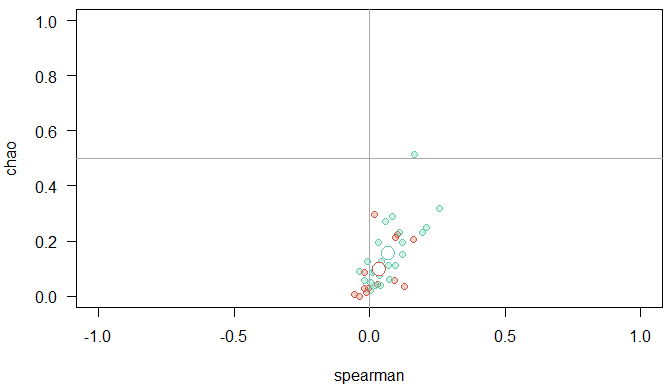

```r
par(mar = c(4, 4, 0.5, 0.5))
SJPlot(out1, gpcol = c('aquamarine3', 'coral3'), cex.legend = 0.8)
```

Set bubble=TRUE to plot scaled symbols. Set unadjF=FALSE and adjF=TRUE to plot corrected estimates (note also that CI=FALSE suppresses confidence intervals). All estimates can be superimposed on a single plot by setting unadj=TRUE, adjf=TRUE, and ssF=TRUE.

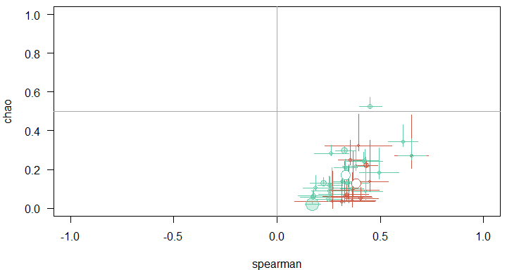

```r
par(mar = c(4, 4, 0.5, 0.5))
SJPlot(out1, gpcol = c('aquamarine3', 'coral3'), bubble = TRUE, unadj = FALSE, adjF = TRUE, cex.legend = 0.8)
```

## FidelityDiv Function

*FidelityDiv* function evaluates live-dead fidelity in terms of alpha diversity and evenness offsets. The resulting object of the class *FidelityDiv* can be plotted using the companion function *AlphaPlot*. When sites are categorized into groups, diversity analyses include by-group analyses and by-group plotting is returned by *AlphaPlot*.

The function will report the offsets in alpha diversity and evenness (stored as $x and $y, respectively) for each live-dead comparisons. The function measures offsets using approach described in Olszewski and Kidwell (2007).

```r
out3 <- FidelityDiv(FidData$live, FidData$dead, iter=1000)
out3$x
```

```
#>             n.std         est         25%         75%     p
#> locality 1     32  1.37354189  1.17865500  1.46633707 0.001
#> locality 2     45  0.66102721  0.60613580  0.73396918 0.001
#> locality 3    102  0.54851072  0.51082562  0.60613580 0.001
#> locality 4    258  0.15743588  0.08961216  0.22314355 0.066
#> locality 5    412  0.59880921  0.59962112  0.59962112 0.001
#> locality 6     40  0.74207719  0.69314718  0.81093022 0.001
#> locality 7     37 -0.01715822 -0.06453852  0.06899287 0.562
#> locality 8    561  0.09733669  0.04255961  0.14165052 0.154
#> locality 9    240  0.54749986  0.50209194  0.60217540 0.001
#> locality 16  1312  0.97346784  0.94000726  1.01523068 0.001
#> locality 17    26  0.34687566  0.20067070  0.45198512 0.006
#> locality 18   265  0.78749920  0.77318989  0.82320031 0.001
#> locality 19   234  0.09941030  0.05884050  0.14107860 0.166
#> locality 20    89  0.77336005  0.65677954  0.81093022 0.001
#> locality 23   156  0.39981708  0.34294475  0.46430561 0.001
#> locality 24    71  0.33173569  0.21130909  0.40546511 0.001
#> locality 25    91  0.38706423  0.35667494  0.42121347 0.001
#> locality 26    61  0.03827237 -0.06453852  0.11778304 0.566
#> locality 27    31 -0.13685361 -0.24116206  0.00000000 0.352
#> locality 28    38 -0.08905365 -0.20763936  0.00000000 0.450
#> locality 29   175  1.11395474  1.02961942  1.25276297 0.001
#> locality 30    62  0.40333740  0.35667494  0.49643689 0.001
#> locality 31   103  0.19181252  0.10536052  0.28768207 0.070
#> locality 32    98  0.30599172  0.25593337  0.34830669 0.001
#> locality 33   187  0.64408810  0.61090908  0.69314718 0.001
#> locality 34    26  0.55951829  0.51082562  0.63598877 0.001
#> locality 35    19  0.47222078  0.44183275  0.55961579 0.001
#> locality 36    24  0.44916588  0.40546511  0.55961579 0.002
#> locality 37    23  0.27554426  0.25131443  0.25131443 0.001
#> locality 38    44 -0.17852148 -0.26236426 -0.08004271 0.240
#> locality 39    68  1.03879787  1.02165125  1.06087196 0.001
#> locality 40    42  0.14799557  0.06453852  0.23638878 0.126
#> locality 41   103  0.24220905  0.21357410  0.28768207 0.001
#> locality 42    97 -0.25861204 -0.36290549 -0.13976194 0.032
#> locality 43   166  0.62653032  0.58778666  0.66782937 0.001
#> locality 44   320 -0.13797869 -0.18805223 -0.05884050 0.100
#> locality 45   274  0.65697656  0.64185389  0.66782937 0.001
#> locality 46   397  0.39131606  0.34294475  0.43531807 0.001
#> locality 47   160  0.17759009  0.12783337  0.24116206 0.046
#> locality 48   189  0.73280812  0.66497630  0.78275934 0.001
#> locality 49   207  0.36251757  0.32277339  0.42121347 0.001
#> locality 50    17  0.78017008  0.69314718  0.84729786 0.001
#> locality 51   218 -0.00777951 -0.06669137  0.06252036 0.838
#> locality 52    42  0.22836791  0.15415068  0.34830669 0.068
```

```r
out3$y
```

```
#>             n.std          est           25%          75%     p
#> locality 1     32  0.317479839  0.2862903226  0.346774194 0.001
#> locality 2     45  0.193653535  0.1808080808  0.208080808 0.001
#> locality 3    102  0.036665502  0.0258202291  0.049504950 0.056
#> locality 4    258  0.002253944 -0.0157376406  0.022916478 0.924
#> locality 5    412  0.174654702  0.1741194813  0.175489571 0.001
#> locality 6     40  0.110271795  0.0833333333  0.130769231 0.001
#> locality 7     37  0.038373874  0.0105105105  0.063063063 0.410
#> locality 8    561 -0.261356812 -0.2765040107 -0.245142602 0.001
#> locality 9    240  0.019810495  0.0107653417  0.028835425 0.156
#> locality 16  1312  0.596675920  0.5898579212  0.603947485 0.001
#> locality 17    26  0.112981538  0.0769230769  0.141538462 0.002
#> locality 18   265  0.156956089  0.1520583190  0.162056890 0.001
#> locality 19   234  0.124004402  0.1098547375  0.139209860 0.001
#> locality 20    89  0.222622319  0.1968207354  0.246169561 0.001
#> locality 23   156  0.048823739  0.0355459057  0.061952026 0.018
#> locality 24    71 -0.004639437 -0.0206237425  0.008853119 0.774
#> locality 25    91  0.003357509 -0.0061660562  0.012942613 0.768
#> locality 26    61 -0.171889071 -0.2092896175 -0.128415301 0.001
#> locality 27    31 -0.168541935 -0.2215053763 -0.109677419 0.004
#> locality 28    38 -0.176347084 -0.2204836415 -0.121977240 0.001
#> locality 29   175  0.668997110  0.6424302135  0.691707718 0.001
#> locality 30    62  0.019018509  0.0009254363  0.041248017 0.486
#> locality 31   103 -0.196606701 -0.2271559109 -0.162906910 0.001
#> locality 32    98  0.044845571  0.0311382285  0.060435514 0.066
#> locality 33   187  0.207709390  0.2010235179  0.214723133 0.001
#> locality 34    26  0.093418462  0.0707692308  0.116923077 0.010
#> locality 35    19  0.095122807  0.0760233918  0.111111111 0.001
#> locality 36    24  0.011550725 -0.0181159420  0.043478261 0.694
#> locality 37    23 -0.160873518 -0.1778656126 -0.142292490 0.001
#> locality 38    44 -0.320595137 -0.3826638478 -0.258985201 0.001
#> locality 39    68 -0.013172959 -0.0144863916  0.001316945 0.558
#> locality 40    42 -0.061622532 -0.0952380952 -0.025551684 0.246
#> locality 41   103  0.183066629  0.1747572816  0.191509614 0.001
#> locality 42    97 -0.256752577 -0.2919351375 -0.219662801 0.001
#> locality 43   166  0.148077401  0.1354326396  0.161080686 0.001
#> locality 44   320 -0.063382974 -0.0824402429 -0.044357367 0.010
#> locality 45   274  0.198017486  0.1925215903  0.203584129 0.001
#> locality 46   397 -0.106153144 -0.1236451416 -0.088078518 0.001
#> locality 47   160 -0.193542689 -0.2230345912 -0.163974057 0.001
#> locality 48   189  0.263134583  0.2567826185  0.269278397 0.001
#> locality 49   207  0.174676798  0.1605693917  0.190047371 0.001
#> locality 50    17  0.181757353  0.1397058824  0.213235294 0.001
#> locality 51   218 -0.233070604 -0.2558343551 -0.210015643 0.001
#> locality 52    42 -0.033267131 -0.0627177700  0.001451800 0.512
```

The returned object also reports mean offsets across all samples and groups of samples (if the factor ‘gp’ is provided). Significance values are also reported for the null hypothesis: offset = 0.

```r
out4 <- FidelityDiv(FidData$live, FidData$dead, FidData$habitat, iter=1000)
out4$xmean
```

```
#>                0.5%     99.5%
#> 0.4062051 0.3617038 0.4449049
```

```r
out4$ymean
```

```
#>                  0.5%      99.5%
#> 0.04638181 0.02998028 0.06024353
```

```r
out4$xgp
```

```
#>   n.sites       est     0.01%     0.99%     group measure
#> 1      27 0.3852434 0.3413147 0.4281250 nearshore Delta S
#> 2      17 0.4394973 0.3448624 0.5291146  offshore Delta S
```

```r
out4$ygp
```

```
#>   n.sites        est       0.01%      0.99%     group   measure
#> 1      27 0.04886363 0.034655862 0.06289484 nearshore Delta PIE
#> 2      17 0.04244008 0.008608863 0.07095627  offshore Delta PIE
```

```r
out4$p.values
```

```
#>      Delta.S.p Delta.PIE.p
#> [1,]     0.001       0.001
```

```r
out4$p.gps
```

```
#>           p.Delta.S p.Delta.PIE
#> nearshore     0.001       0.001
#> offshore      0.001       0.001
```

## AlphaPlot Function

The output produced by *FidelityDiv* function can be used to generate diversity-evenness offset plot (see Olszewski and Kidwell 2007). The function *AlphaPlot* uses objects produced by *FidelityDiv* to plot estimates of offsets for samples.

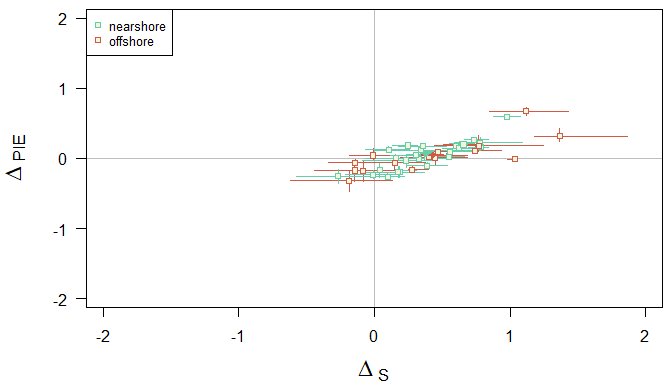

```r
out3 <- FidelityDiv(FidData$live, FidData$dead, FidData$habitat, CI = 0.95, iter = 1000)
par(mar = c(4, 4.5, 0.5, 0.5))
AlphaPlot(out3, col.gp = c('aquamarine3', 'coral3'), bgpt = 'beige', pch = 22, legend.cex = 0.8)
```

## Comments

Comments and questions about PaleoFidelity should be directed to kowalewski@ufl.edu.

## References

Kowalewski, M., Carroll, M., Casazza, L., Gupta, N., Hannisdal, B., Hendy, A., Krause, R.A., Jr., Labarbera, M., Lazo, D.G., Messina, C., Puchalski, S., Rothfus, T.A., Sälgeback, J., Stempien, J., Terry, R.C., Tomašových, A., (2003), Quantitative fidelity of brachiopod-mollusk assemblages from modern subtidal environments of San Juan Islands, USA. *Journal of Taphonomy* **1**, 43-65.

Olszewski T.D., Kidwell S.M., 2007, The preservational fidelity of evenness in molluscan death assemblages. *Paleobiology* **33**, 1–23. (doi:10.1666/05059.1)

Tyler, C.T., Kowalewski, M., 2017, Surrogate taxa and fossils as reliable proxies of spatial biodiversity patterns in marine benthic communities. *Proceedings of the Royal Society B* **284**: 20162839. (doi:10.1098/rspb.2016.2839).

Tyler, C.L., Kowalewski, M., 2018, Regional surveys of macrobenthic shelf invertebrate communities in Onslow Bay, North Carolina, U.S.A. *Scientific Data* **5**:180054 (doi:10.1038/sdata.2018.54)